# Informe clustering

# Clustering

Para realizar el agrupamiento surgió la idea de manera natural de considerar tres grupos, los cuales representarían las zonas con menor riesgo, con riesgo medio y con riesgo alto de accidentarse.

Dicho esto, se contó la cantidad total de accidentes por barrio en el periodo de tiempo existente en los datos y con base en esto se crearon algunas métricas. La primera de ellas indica la proporción de accidentes graves, donde se consideró como de esta categoría aquellos choques en los cuales hubo defunciones. Asimismo, se construyó un indicador de la la probabilidad de ocurrencia de las clases de acciedentes más comunes, es decir, choque o atropello. Finalmente, se crea una última variable que consiste en la cantidad de accidentes llevados a una escala unitaria, ya que como los otros indicadores son proporciones, esto asegura que este también se encuentre en la misma escala, pues esto es preferible al aplicar el algoritmo de k medias.

Dicho esto, se consideraron, inicialmente, todas las combinaciones posibles de a dos, de las métricas mencionadas anteriormente, obteniendo que las variables tasa de graves y los choques en el intervalo unitario generan tres grupos que son razonables y hacen sentido.

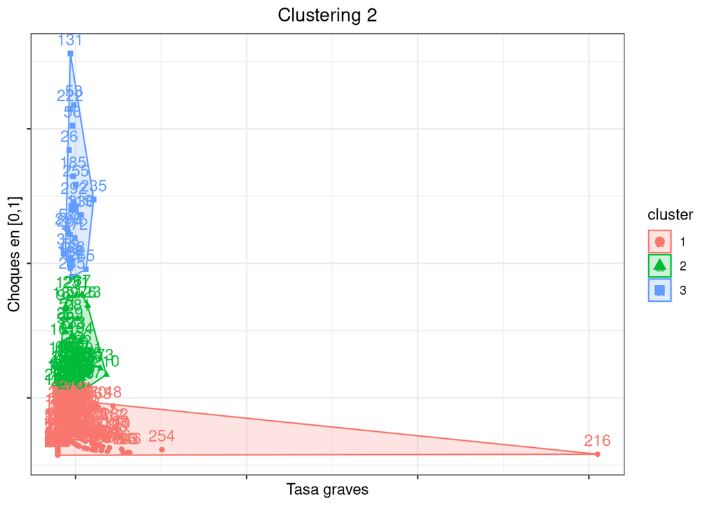

Grupos definitivos clustering

Finalmente se presentan las distribuciones de la accidentalidad por cluster.

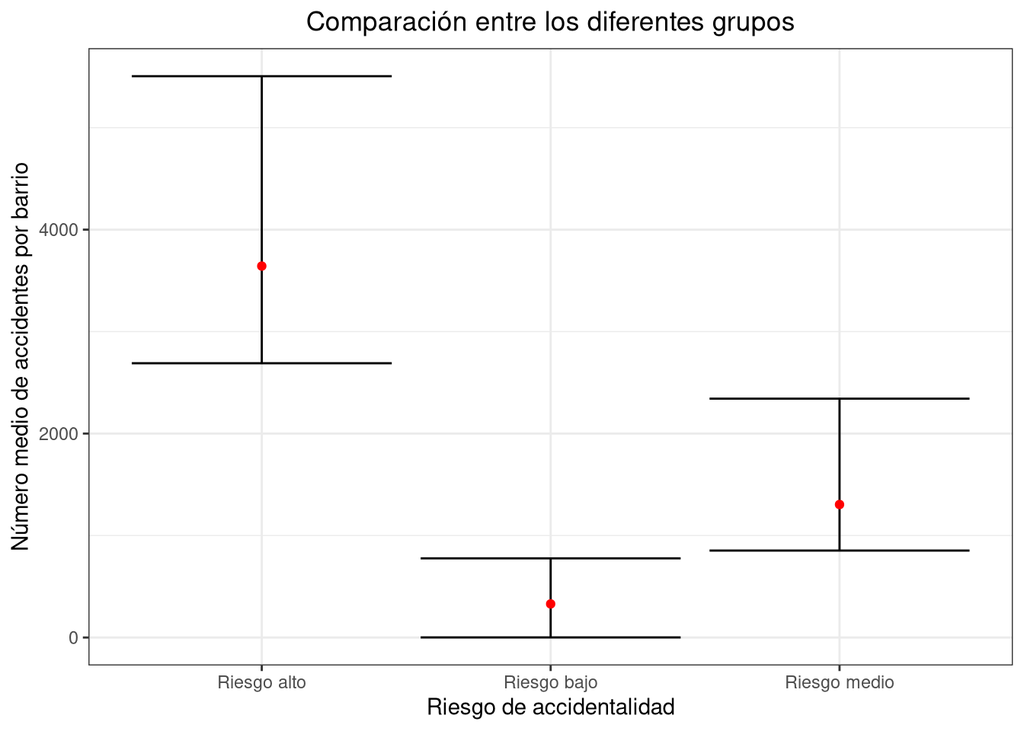

Como se puede observar en el gráfico anterior, no hay traslapes entre las regiones de confianza definidas por grupo, lo cual es un indicio de que existen diferencias significativas entre la cantidad de accidentes medios por grupo, mostrando así lo adecuados que resultó el agrupamiento.